# Sistema de alerta temprana de la mancha foliar del caqui: regresión Beta bayesiana con INLA

Joaquín Martínez-Minaya

2026-11-19

Las **cuatro preguntas** aparecen intercaladas junto a las salidas necesarias para resolverlas. El código R está proporcionado; cada pregunta incluye una solución desplegable.

Esta práctica está basada en una versión simplificada del artículo [Martínez-Minaya et al. (2021)](https://apsjournals.apsnet.org/doi/full/10.1094/PHYTO-08-20-0359-R). El desarrollo completo puede consultarse en el [repositorio del proyecto](https://bitbucket.org/joaquin-martinez-minaya/betapathogen/src).

```r
  library(dplyr)
  library(ggplot2)
  library(INLA)
  library(readxl)
```

# 1 Contexto: un sistema de alerta temprana

La **mancha foliar del caqui** (*Circular Leaf Spot*, CLS), causada por el hongo *Plurivorosphaerella nawae*, puede provocar lesiones necróticas, defoliación y caída de frutos. Durante la primavera, el hongo libera ascosporas que pueden infectar las hojas del caqui. Por tanto, anticipar la liberación de ascosporas resulta útil para programar los tratamientos fitosanitarios.

Se desea construir un **sistema de alerta temprana** que utilice los **grados-día acumulados** para determinar cuándo debe empezar el agricultor a tratar. Se dispone de datos recogidos en L’Alcúdia (Valencia) entre 2010 y 2015.

# 2 Datos de L’Alcúdia

Las variables utilizadas son:

- `y`: proporción acumulada de ascosporas liberadas, disponible en el fichero de datos y con valores estrictamente entre 0 y 1.
- `year`: año de observación.
- `dd`: grados-día acumulados desde el 1 de enero, con temperatura base 0 °C, **expresados en centenas de grados-día**. Por ejemplo, `dd = 15` equivale a 1 500 grados-día.

**En toda la práctica se utilizan directamente los valores del archivo Excel.** Los umbrales del sistema de alerta se proporcionan en la hoja `umbrales` del mismo archivo.

```r
data <- readxl::read_excel("datos_alcudia_transformados_BANDAS.xlsx", sheet = "datos")
data$year <- factor(data$year)
data <- data %>%
  dplyr::select(y, year, dd)
head(data)
```

| y | year | dd |
| --- | --- | --- |
| 0.001672241 | 2010 | 6.8632 |
| 0.001672241 | 2010 | 7.4725 |
| 0.011477706 | 2010 | 8.4572 |
| 0.031088637 | 2010 | 9.3737 |
| 0.070310499 | 2010 | 10.4184 |
| 0.100427285 | 2010 | 11.2742 |

# 3 Análisis descriptivo

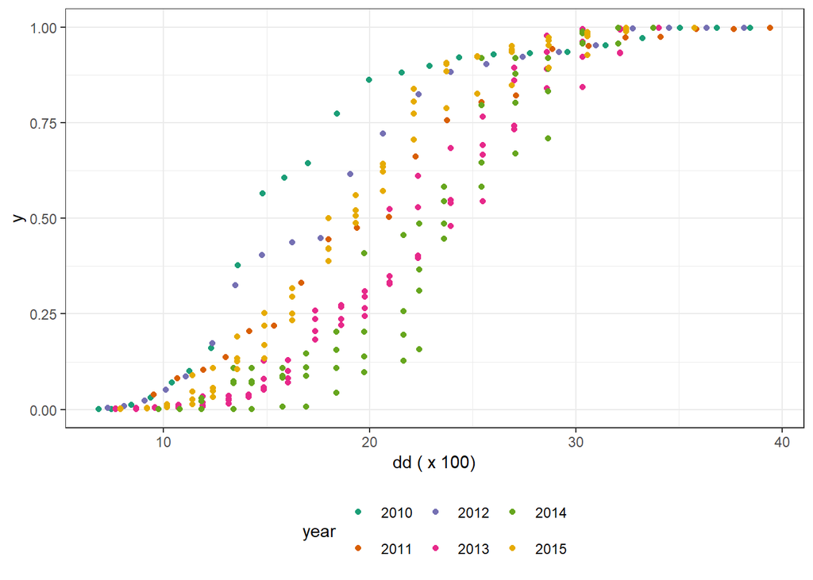

```r
  ggplot(data) +
  geom_point(aes(x = dd, y = y, col = year))+
  theme_bw() +
  theme(legend.position = "bottom") +
  scale_color_brewer(palette="Dark2") +
  xlab("dd ( x 100)")
```

# 4 Modelo: regresión Beta bayesiana jerárquica

Para modelizar una proporción continua en (0, 1), utilizamos una distribución Beta parametrizada por su **media** $\mu_i$ y su **precisión** $\phi$. Su parametrización es $\operatorname{Beta}(\mu_i\phi,(1-\mu_i)\phi)$, con enlace logit para $\mu_i$. Aunque la respuesta es Beta, el predictor y sus efectos aleatorios forman un **campo latente gaussiano**.

```r
# Priors explícitas para que los tres niveles del LGM sean identificables
prior_fijos <- list(mean = 0, prec = 0.001,
                     mean.intercept = 0, prec.intercept = 0.001)
# phi ~ Gamma(1, 0.01), con Gamma parametrizada por forma y tasa.
prior_beta <- list("precision parameter" = list(prior = "loggamma", param = c(1, 0.01)))
```

# 5 Ajuste de los tres modelos

## 5.1 Modelo 0: intercepto

```r
formula0 <- y ~ + 1
mod0 <- inla(formula0,
             family            = "beta",
             data              = data,
             control.family    = list(link  = "logit", hyper = prior_beta),
             control.fixed     = prior_fijos,
             control.compute   = list(dic    = TRUE,
                                      cpo    = TRUE,
                                      waic   = TRUE),
             control.predictor = list(compute = TRUE))
```

## 5.2 Modelo 1: grados-día

```r
formula1 <- y ~ + 1 + dd

mod1 <- inla(formula1,
             family            = "beta",
             data              = data,
             control.family    = list(link  = "logit", hyper = prior_beta),
             control.fixed     = prior_fijos,
             control.compute   = list(dic    = TRUE,
                                      cpo    = TRUE,
                                      waic   = TRUE),
             control.predictor = list(compute = TRUE))
```

## 5.3 Modelo 2: grados-día y año aleatorio

Para introducir un efecto aleatorio del año, creamos el siguiente índice:

```r
  data$year_ind <- as.numeric(data$year)
```

```r
prior1_tau <- list(prec = list(prior = 'pc.prec', param = c(5, 0.01)))

formula2 <- y ~ + 1 + dd +
  f(year_ind, model='iid',
    hyper = prior1_tau)

mod2 <- inla(formula2,
             family            = "beta",
             data              = data,
             control.family    = list(link  = "logit", hyper = prior_beta),
             control.fixed     = prior_fijos,
             control.compute   = list(config = TRUE,
                                      dic    = TRUE,
                                      cpo    = TRUE,
                                      waic   = TRUE),
             control.predictor = list(compute = TRUE))
```

# 6 Pregunta 1. Formulación de los tres niveles

Los tres modelos anteriores se han ajustado mediante R-INLA. **Escribe su formulación matemática siguiendo exactamente los tres niveles de las diapositivas:**

1. **Nivel 1 — verosimilitud:** especifica $p(\mathbf y\mid\boldsymbol\theta,\boldsymbol\psi_1)$, la distribución Beta, la función de enlace y el predictor lineal.
2. **Nivel 2 — campo latente gaussiano:** identifica $\boldsymbol\theta$ y escribe $p(\boldsymbol\theta\mid\boldsymbol\psi_2)$, indicando su media y su matriz de precisión.
3. **Nivel 3 — hiperparámetros:** identifica $\boldsymbol\psi=(\boldsymbol\psi_1,\boldsymbol\psi_2)$ y escribe sus **distribuciones a priori explícitas**.

**Para cada modelo, indica cuántas observaciones, componentes latentes e hiperparámetros hay en cada nivel.**

**Ver solución orientativa — Pregunta 1**

**Notación:** $n=299$ observaciones; $a(i)\in\{1,\ldots,6\}$ identifica el año de la observación $i$; $d_i=dd_i$ representa centenas de grados-día. En los tres modelos $\psi_1=(\phi)$; la distribución Gamma se parametriza con **forma y tasa**.

**Modelo 0 — $N=1$ variable latente y $1$ hiperparámetro**

- **Nivel 1 (verosimilitud, $n$ respuestas):**
  $$p(\mathbf y\mid\boldsymbol\theta_0,\boldsymbol\psi_1)=\prod_{i=1}^n \mathrm{Beta}(y_i\mid\mu_i\phi,(1-\mu_i)\phi),\qquad\mathrm{logit}(\mu_i)=\eta_i=\beta_0.$$
- **Nivel 2 (campo latente, dimensión $N=1$):**
  $$\boldsymbol\theta_0=(\beta_0),\qquad \beta_0\sim N(0,1000).$$
- **Nivel 3 (hiperparámetros, dimensión $1$):**
  $$\boldsymbol\psi=(\phi),\qquad\phi\sim\mathrm{Gamma}(1,0.01).$$

**Modelo 1 — $N=2$ variables latentes y $1$ hiperparámetro**

- **Nivel 1 (verosimilitud, $n$ respuestas):**
  $$p(\mathbf y\mid\boldsymbol\theta_1,\boldsymbol\psi_1)=\prod_{i=1}^n \mathrm{Beta}(y_i\mid\mu_i\phi,(1-\mu_i)\phi),\qquad\mathrm{logit}(\mu_i)=\eta_i=\beta_0+\beta_1d_i.$$
- **Nivel 2 (campo latente, dimensión $N=2$):**
  $$\boldsymbol\theta_1=(\beta_0,\beta_1)^T\sim N_2(\mathbf0,\mathrm{diag}(0.001,0.001)^{-1}).$$
- **Nivel 3 (hiperparámetros, dimensión $1$):**
  $$\boldsymbol\psi=(\phi),\qquad\phi\sim\mathrm{Gamma}(1,0.01).$$

**Modelo 2 — $N=8$ variables latentes y $2$ hiperparámetros**

- **Nivel 1 (verosimilitud, $n$ respuestas):**
  $$p(\mathbf y\mid\boldsymbol\theta_2,\boldsymbol\psi_1)=\prod_{i=1}^n \mathrm{Beta}(y_i\mid\mu_i\phi,(1-\mu_i)\phi),\qquad\mathrm{logit}(\mu_i)=\eta_i=\beta_0+\beta_1d_i+u_{a(i)}.$$
- **Nivel 2 (campo latente, dimensión $N=8$):**
  $$\boldsymbol\theta_2=(\beta_0,\beta_1,u_1,\ldots,u_6)^T\mid\tau_u\sim N_8(\mathbf0,\mathbf Q(\tau_u)^{-1}),$$
  $$\mathbf Q(\tau_u)=\mathrm{diag}(0.001,0.001,\tau_u,\ldots,\tau_u),\quad u_j\mid\tau_u\overset{iid}{\sim}N(0,\tau_u^{-1}).$$
- **Nivel 3 (hiperparámetros, dimensión $2$):**
  $$\boldsymbol\psi=(\phi,\tau_u),\quad \phi\sim\mathrm{Gamma}(1,0.01),\quad\tau_u\sim\mathrm{PC.prec}(5,0.01),$$
  donde la última prior se caracteriza por $P(\sigma_u>5)=0.01$, siendo $\sigma_u=\tau_u^{-1/2}$. Se asumen priors independientes para $\phi$ y $\tau_u$.

**Resumen de dimensiones:**

| Modelo | Nivel 1: observaciones | Nivel 2: componentes del campo latente | Nivel 3: hiperparámetros |
| --- | --- | --- | --- |
| 0 | $n=299$ | $1$ ($\beta_0$) | $1$ ($\phi$) |
| 1 | $n=299$ | $2$ ($\beta_0,\beta_1$) | $1$ ($\phi$) |
| 2 | $n=299$ | $8$ ($\beta_0,\beta_1,u_1,\ldots,u_6$) | $2$ ($\phi,\tau_u$) |

**Importante:** $\phi$ (precisión de la Beta) y $\tau_u$ (precisión del efecto anual) tienen funciones diferentes. Los $n$ predictores $\eta_i$ son funciones del campo latente, no $n$ coeficientes libres adicionales.

# 7 Comparación de los modelos

```r
  selection <- data.frame(DIC  = c(mod0$dic$dic, mod1$dic$dic, mod2$dic$dic),
                        WAIC = c(mod0$waic$waic, mod1$waic$waic, mod2$waic$waic),
                        LCPO = c(-mean(log(mod0$cpo$cpo)),
                                 -mean(log(mod1$cpo$cpo)),
                                 -mean(log(mod2$cpo$cpo))))
rownames(selection)<- c("Null model", "DD", "DD + year")
selection
```

|  | DIC | WAIC | LCPO |
| --- | --- | --- | --- |
| Null model | -295.5375 | -296.1106 | -0.4951679 |
| DD | -888.8569 | -888.7862 | -1.4862632 |
| DD + year | -1119.6389 | -1118.3057 | -1.8699904 |

# 8 Resúmenes posteriores del Modelo 2

## 8.1 Distribución posterior de los efectos fijos

```r
  mod2$summary.fixed %>% round(., 4)
```

|  | mean | sd | 0.025quant | 0.5quant | 0.975quant | mode | kld |
| --- | --- | --- | --- | --- | --- | --- | --- |
| (Intercept) | -6.6331 | 0.4299 | -7.4957 | -6.6319 | -5.7770 | -6.6319 | 1e-04 |
| dd | 0.3331 | 0.0067 | 0.3196 | 0.3332 | 0.3459 | 0.3331 | 0e+00 |

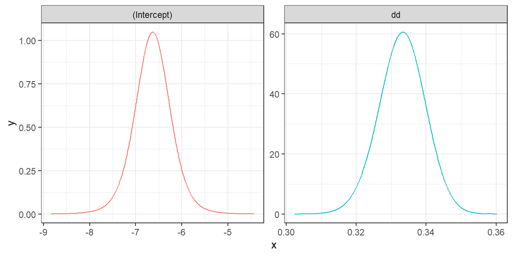

```r
post_margs <- do.call(rbind, lapply(names(mod2$marginals.fixed), function(nombre) {
  densidad <- as.data.frame(inla.smarginal(mod2$marginals.fixed[[nombre]]))
  densidad$variable <- nombre
  densidad
}))

ggplot(post_margs, aes(x = x, y = y)) +
  geom_line(aes(color = variable)) +
  facet_wrap(~variable, ncol = 2, scales = "free") +
  theme_bw() +
  theme(legend.position = "none")
```

## 8.2 Distribución posterior de los hiperparámetros

```r
  mod2$summary.hyperpar %>% round(., 4)
```

|  | mean | sd | 0.025quant | 0.5quant | 0.975quant | mode |
| --- | --- | --- | --- | --- | --- | --- |
| precision parameter for the beta observations | 26.0432 | 2.3433 | 21.6916 | 25.9534 | 30.9094 | 25.8058 |
| Precision for year_ind | 1.4273 | 0.9415 | 0.3168 | 1.1995 | 3.8557 | 0.8026 |

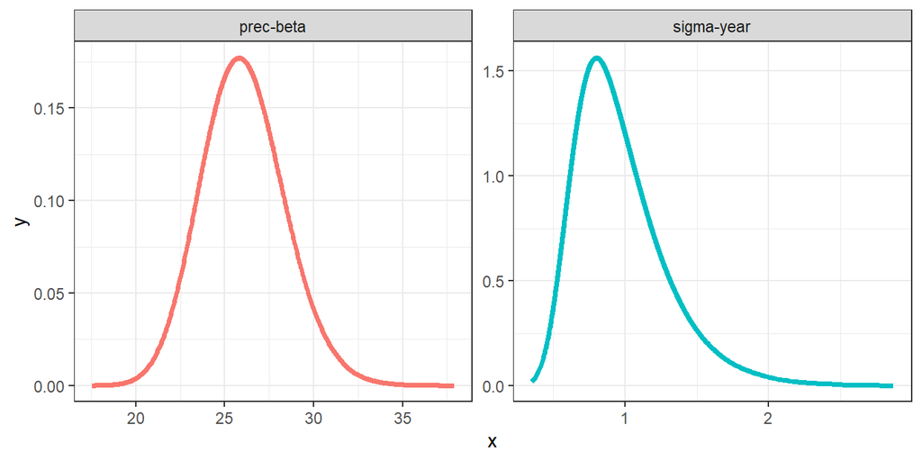

```r
# Desviación típica del efecto aleatorio del año
nombre_tau <- grep("Precision for year_ind", names(mod2$marginals.hyperpar),
                   value = TRUE, ignore.case = TRUE)
stopifnot(length(nombre_tau) == 1L)
sd_re <- inla.tmarginal(function(x) 1/sqrt(x),
                        mod2$marginals.hyperpar[[nombre_tau]])

# Precisión de la distribución Beta
nombre_phi <- grep("beta observations", names(mod2$marginals.hyperpar),
                   value = TRUE, ignore.case = TRUE)
stopifnot(length(nombre_phi) == 1L)
prec_beta <- inla.smarginal(mod2$marginals.hyperpar[[nombre_phi]])

# Unimos las dos distribuciones
hyperpars <- rbind(data.frame(sd_re, hyp1 = "sigma-year"),
                     data.frame(prec_beta, hyp1 = "prec-beta"))
hyperpars$hyp1 <- factor(hyperpars$hyp1)

# Gráfico
ggplot(hyperpars, aes(x = x, y = y)) +
    geom_line(aes(color = hyp1), linewidth = 1.3) +
    facet_wrap(~ hyp1, ncol = 2, scales = "free") +
    theme_bw() +
    theme(legend.position = "none")
```

# 9 Probabilidad posterior de que el efecto de los grados-día sea positivo

```r
  p1 <- 1 - inla.pmarginal(0, mod2$marginals.fixed$dd)
```

Para el Modelo 2, $P(\beta_1 > 0 \mid \mathbf{y}) =$ 1.

# 10 Distribución posterior de las odds ratios por 100 grados-día

```r
# dd está medido en centenas de grados-día: OR_100 = exp(beta_1).
# Transformamos toda la marginal posterior, no únicamente su media.
posterior_or100 <- inla.tmarginal(function(x) exp(x), mod2$marginals.fixed[["dd"]])
media_or100 <- inla.emarginal(identity, posterior_or100)
ic_or100 <- inla.qmarginal(c(0.025, 0.975), posterior_or100)
prob_or100_mayor1 <- 1 - inla.pmarginal(1, posterior_or100)

resumen_or100 <- data.frame(
  `Media posterior` = media_or100,
  `Percentil 2.5 %` = ic_or100[1],
  `Percentil 97.5 %` = ic_or100[2],
  `P(OR > 1)` = prob_or100_mayor1,
  check.names = FALSE
)
round(resumen_or100, 4)
```

| Media posterior | Percentil 2.5 % | Percentil 97.5 % | P(OR > 1) |
| --- | --- | --- | --- |
| 1.3953 | 1.3766 | 1.4132 | 1 |

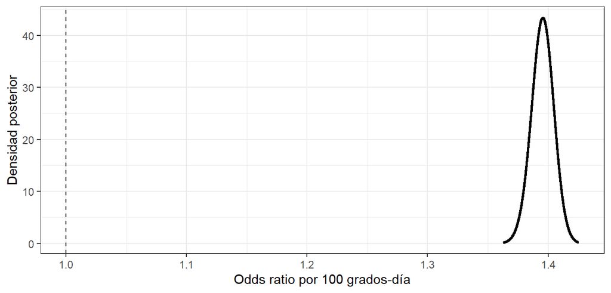

```r
or_dens <- as.data.frame(inla.smarginal(posterior_or100))
colnames(or_dens)[1:2] <- c("x", "y")
ggplot(or_dens, aes(x = x, y = y)) +
  geom_line(linewidth = 1.05) +
  geom_vline(xintercept = 1, linetype = "dashed") +
  labs(x = "Odds ratio por 100 grados-día", y = "Densidad posterior") +
  theme_bw()
```

# 11 Pregunta 2. Interpretación de los grados-día

Para el **Modelo 2**:

1. Obtén la media a posteriori, el intervalo de credibilidad del 95 % de $\beta_1$ y $P(\beta_1>0\mid\mathbf y)$.
2. Calcula la **distribución posterior de la razón de odds (*odds ratio*)** asociada a un incremento de **100 grados-día**. Indica su media posterior, intervalo de credibilidad del 95 % y $P(\mathrm{OR}_{100}>1\mid\mathbf y)$.
3. **Interpreta los resultados** en el contexto de la liberación de ascosporas y de la enfermedad del caqui.

**Ver solución orientativa — Pregunta 2**

El coeficiente de interés aparece como `dd` en `mod2$summary.fixed`. La media posterior es 0.33305; el intervalo creíble del 95 % es [0.31958, 0.34593] y $P(\beta_1>0\mid\mathbf y)=$ 1.

Como `dd` está expresado en **centenas de grados-día**, un incremento de 100 grados-día corresponde a $\Delta dd=1$. Por tanto:

$$\mathrm{OR}_{100}=\frac{\mu(dd+1)/[1-\mu(dd+1)]}{\mu(dd)/[1-\mu(dd)]}=\exp(\beta_1).$$

La **distribución posterior** de $\mathrm{OR}_{100}$ se obtiene transformando la marginal de $\beta_1$, no exponenciando solamente su media. Su media posterior es 1.3953, su intervalo de credibilidad del 95 % es [1.3766, 1.4132] y $P(\mathrm{OR}_{100}>1\mid\mathbf y)=$ 0.99999.

Si la OR es mayor que 1, al acumular 100 grados-día adicionales **aumentan las odds de la proporción media modelizada**, manteniendo constante el efecto anual. Por ejemplo, una OR de 1.2 significa un aumento del 20 % de esas odds, **no** un incremento de 20 puntos porcentuales en las ascosporas liberadas. Esto apoya el uso de grados-día para anticipar la disponibilidad del inóculo.

# 12 Pregunta 3. Efecto aleatorio anual

**¿Mantendrías el efecto aleatorio del año en el modelo?** Justifica tu decisión utilizando los resultados obtenidos. Explica qué representa ese efecto y por qué podría ser relevante para un sistema de alerta temprana.

**Ver solución orientativa — Pregunta 3**

Para responder a esta pregunta nos fijamos conjuntamente en: (i) los cambios en DIC, WAIC y, opcionalmente, LCPO entre los Modelos 1 y 2; (ii) la distribución posterior de $\sigma_u$, desviación típica entre años. Valores observados al ejecutar el documento: DIC (Modelo 1) = -888.86; DIC (Modelo 2) = -1119.64; WAIC (Modelo 1) = -888.79; WAIC (Modelo 2) = -1118.31. Media posterior de $\sigma_u$ = 0.9701. Por tanto, incluiremos el efecto aleatorio año en nuestro modelo.